# Indicators

#Initial SETUP

```r
#clean
rm(list = ls())
```

```r
# Set the working directory
#setwd()
getwd()
```

```
[1] "C:/Users/srgen/OneDrive/Documentos/Applied Economics/Econometrics/Econometrics II class/Corona EcoII-2/Homework/Findex/Findex"
```

```r
#Library setup
libs <- c("WDI", "forecast", "ggplot2", "portes", "tseries", "vars", "FactoMineR", "rticles", "tsDyn")
class(libs)
```

```
[1] "character"
```

```r
length(libs)
```

```
[1] 9
```

```r
for (i in libs) {
  if(!is.element(i,.packages(all.available = TRUE))) {
    install.packages(i,repos="https://cran.revolutionanalytics.com/")
  }
  library(i,character.only = TRUE)
}
# path
#path <-"C:/Users/srgen/OneDrive/Documentos/Applied Economics/Econometrics/Econometrics II class/Corona EcoII-2/Homework/Findex/Findex/"
# some functions
source("functions.r")
```

# Findex Indicators:

#LLG LEV: FIRST NAME: “Liquid liabilities to GDP (%)” CODE: “GFDD.DI.05” #PCDM LEV: SECOND NAME: “Private credit by deposit money banks and other financial institutions to GDP (%)” CODE: “GFDD.DI.12” #DCFS LEV: THIRD NAME: “Domestic credit provided by financial sector (% of GDP)” CODE: “FS.AST.DOMS.GD.ZS” #DCPS LEV: FOURTH NAME: “Domestic credit to private sector (% of GDP)” CODE: “FS.AST.PRVT.GD.ZS”

# Regresadas

#GDPMX LEVL:No COL: NAME: “GDP per capita (constant 2010 US$)” CODE: "“NY.GDP.PCAP.KD”"

# Control

#M2 LEV: NO NAME: Masa Monetaria con respecto al PIB CODE: "FM.LBL.BMNY.GD.ZS

#GCF NAME:“Gross capital formation (% of GDP)” CODE: “NE.GDI.TOTL.ZS”

#GDPUS LEVL:No NAME: “GDP per capita (constant 2010 US$)” CODE: "“NY.GDP.PCAP.KD”

library(“WDI”) for World Bank Development Indicators for R https://github.com/vincentarelbundock/WDI How to look for data: WDIsearch(‘gdp.*capita.*constant’)

```r
#import DataFrame
LLG<-WDI(indicator = c("GFDD.DI.05"), country=c('MX'), start=1961, end=2016)
PCDM<-WDI(indicator = c('GFDD.DI.12'), country=c('MX'), start=1961, end=2016)
DCFS<-WDI(indicator = c("FS.AST.DOMS.GD.ZS"), country=c('MX'), start=1961, end=2016)
DCPS<-WDI(indicator = c("FS.AST.PRVT.GD.ZS"), country=c('MX'), start=1961, end=2016)
M2<-WDI(indicator = c("FM.LBL.BMNY.GD.ZS"), country=c('MX'), start=1961, end=2016)
GDPMX<-WDI(indicator = c("NY.GDP.PCAP.KD"), country=c('MX'), start=1961, end=2016)
GDPUS<-WDI(indicator = c("NY.GDP.PCAP.KD"), country=c('US'), start=1961, end=2016)
GCF<-WDI(indicator = c("NE.GDI.TOTL.ZS"), country=c('MX'), start=1961, end=2016)
#reArrange
names(LLG)<-c("code", "C","LLG","yr")
LLG<-LLG[order(LLG$yr),]
names(PCDM)<-c("code", "C","PCDM","yr")
PCDM<-PCDM[order(PCDM$yr),]
names(DCFS)<-c("code", "C","DCFS","yr")
DCFS<-DCFS[order(DCFS$yr),]
names(DCPS)<-c("code", "C","DCPS","yr")
DCPS<-DCPS[order(DCPS$yr),]
names(M2)<-c("code", "C","M2","yr")
M2<-M2[order(M2$yr),]
names(GDPMX)<-c("code", "C","GDPMX","yr")
GDPMX<-GDPMX[order(GDPMX$yr),]
names(GDPUS)<-c("code", "C","GDPUS","yr")
GDPUS<-GDPUS[order(GDPUS$yr),]
names(GCF)<-c("code", "C","GCF","yr")
GCF<-GCF[order(GCF$yr),]
LLG$LLG<-log(LLG$LLG)
PCDM$PCDM<-log(PCDM$PCDM)
DCFS$DCFS<-log(DCFS$DCFS)
GDPMX$GDPMX<-log(GDPMX$GDPMX)
GCF$GCF<-log(GCF$GCF)
GDPUS$GDPUS<-log(GDPUS$GDPUS)
DCPS$DCPS<-log(DCPS$DCPS)
M2$M2<-log(M2$M2)
```

# Construcción de Serie de Tiempo

```r
ts<-cbind(LLG$LLG, PCDM$PCDM, DCFS$DCFS, DCPS$DCPS, M2$M2, GDPMX$GDPMX, GCF$GCF, GDPUS$GDPUS)
ts<-ts((ts), names=c("LLG","PCDM", "DCFS", "DCPS","M2", "GDPMX","GCF", "GDPUS"), start= min(GDPMX$yr), end=max(GDPMX$yr), frequency=1)
head(ts)
```

```
Time Series:
Start = 1961
End = 1966
Frequency = 1
          LLG     PCDM     DCFS     DCPS       M2    GDPMX      GCF    GDPUS
1961 3.106755 3.019678 3.235238 3.103801 3.174044 8.277389 2.865836 9.779004
1962 3.169875 3.124156 3.317816 3.202960 3.227053 8.291606 2.800626 9.822836
1963 3.196925 3.142453 3.339422 3.190554 3.271790 8.338308 2.910904 9.851504
1964 3.187955 3.111139 3.379041 3.185496 3.258403 8.419702 2.937290 9.893994
1965 3.219452 3.139343 3.459766 3.174844 3.261893 8.457372 3.008690 9.943527
1966 3.199762 3.145182 3.526070 3.216241 3.240869 8.485917 2.968178 9.994953
```

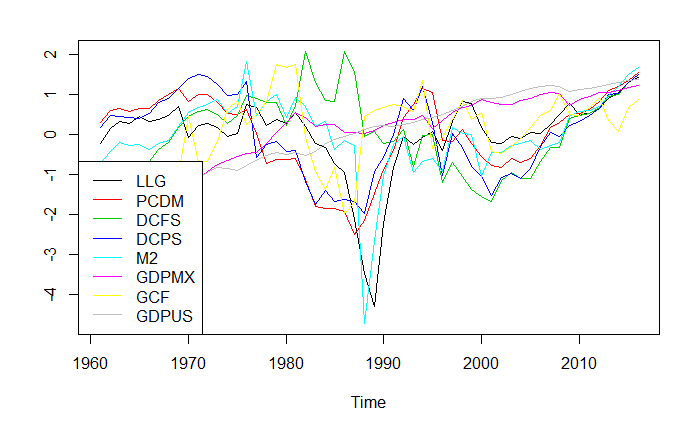

```r
ts.plot(scale(ts),col=c(1,2,3,4,5,6,7,8), lwd=c(1,1,1,1,1,1,1))
legend("bottomleft", colnames(ts), col = c(1:8), lty = 1)
```

```r
cor(ts)
```

```
             LLG        PCDM        DCFS       DCPS          M2       GDPMX       GCF
LLG   1.00000000  0.65625456  0.02474237  0.5252842 0.780772150  0.04117311 0.1038768
PCDM  0.65625456  1.00000000 -0.11134443  0.9242690 0.444384749 -0.22295611 0.1073317
DCFS  0.02474237 -0.11134443  1.00000000  0.0931001 0.450329939  0.24916932 0.1941382
DCPS  0.52528416  0.92426895  0.09310010  1.0000000 0.503914945 -0.30392841 0.1282876
M2    0.78077215  0.44438475  0.45032994  0.5039149 1.000000000  0.09103480 0.1481106
GDPMX 0.04117311 -0.22295611  0.24916932 -0.3039284 0.091034802  1.00000000 0.6233973
GCF   0.10387682  0.10733169  0.19413824  0.1282876 0.148110622  0.62339732 1.0000000
GDPUS 0.05066431 -0.09031695  0.07191600 -0.2254064 0.005240051  0.94724826 0.5083844
             GDPUS
LLG    0.050664305
PCDM  -0.090316950
DCFS   0.071915999
DCPS  -0.225406432
M2     0.005240051
GDPMX  0.947248261
GCF    0.508384379
GDPUS  1.000000000
```

# RAiz Unitaria a todas las series.

Todas son I(1)

```r
adf_mat <- matrix(0, ncol(ts), 2)
rownames(adf_mat) <- colnames(ts)
colnames(adf_mat) <- c("levels", "fd")
for(i in 1 : ncol(ts)){
  adf_mat[i,"levels"] <- adf(ts[,i], "none")$p.value
  adf_mat[i,"fd"] <- adf(diff(ts[,i]), "none")$p.value
}
```

```
p-value smaller than printed p-valuep-value smaller than printed p-valuep-value smaller than printed p-valuep-value smaller than printed p-valuep-value greater than printed p-valuep-value smaller than printed p-valuep-value smaller than printed p-valuep-value greater than printed p-value
```

```r
adf_mat
```

```
         levels         fd
LLG   0.6910006 0.01000000
PCDM  0.6230081 0.01484841
DCFS  0.8801684 0.01000000
DCPS  0.6242531 0.01000000
M2    0.7455357 0.01000000
GDPMX 0.9900000 0.01000000
GCF   0.7849457 0.01000000
GDPUS 0.9900000 0.02929500
```

# Serie de Tiempo para contrucción del índice financiero

Datos escalados para su uso posterior

```r
tsf<-cbind(LLG$LLG,PCDM$PCDM, M2$M2, DCPS$DCPS)
tsf<-ts(tsf,names=c("LLG","PCDM", "M2", "PRUEBA"), start= min(PCDM$yr), end=max(PCDM$yr), frequency=1)
head(tsf)
```

```
Time Series:
Start = 1961
End = 1966
Frequency = 1
          LLG     PCDM       M2   PRUEBA
1961 3.106755 3.019678 3.174044 3.103801
1962 3.169875 3.124156 3.227053 3.202960
1963 3.196925 3.142453 3.271790 3.190554
1964 3.187955 3.111139 3.258403 3.185496
1965 3.219452 3.139343 3.261893 3.174844
1966 3.199762 3.145182 3.240869 3.216241
```

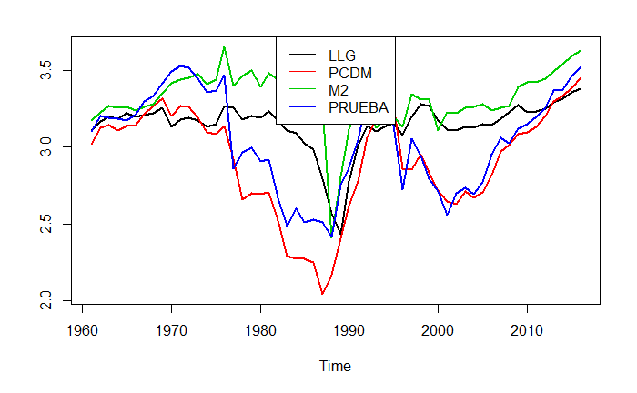

```r
ts.plot((tsf),  col=c(1,2,3,4), lwd=c(2,2,2,2))
legend("top", colnames(tsf), col = c(1:4), lty = 1)
```

# RAiz Unitaria a series financieras.

Todas son I(1)

```r
adf_matf <- matrix(0, ncol(tsf), 2)
rownames(adf_matf) <- colnames(tsf)
colnames(adf_matf) <- c("levels", "fd")
for(i in 1 : ncol(tsf)){
  adf_matf[i,"levels"] <- adf(tsf[,i], "none")$p.value
  adf_matf[i,"fd"] <- adf(diff(tsf[,i]), "none")$p.value
}
```

```
p-value smaller than printed p-valuep-value smaller than printed p-valuep-value smaller than printed p-value
```

```r
adf_matf
```

```
          levels         fd
LLG    0.6910006 0.01000000
PCDM   0.6230081 0.01484841
M2     0.7455357 0.01000000
PRUEBA 0.6242531 0.01000000
```

# Construccion del Indice

```r
pc1<-PCA(tsf, scale.unit=TRUE, ncp=4, graph = FALSE)
head(pc1$eig)
```

```
       eigenvalue percentage of variance cumulative percentage of variance
comp 1 2.92280468              73.070117                          73.07012
comp 2 0.79635832              19.908958                          92.97907
comp 3 0.25736116               6.434029                          99.41310
comp 4 0.02347584               0.586896                         100.00000
```

```r
head(pc1$var$contrib)
```

```
          Dim.1    Dim.2     Dim.3     Dim.4
LLG    25.46334 17.66699 43.488505 13.381171
PCDM   27.41197 21.41951  6.932233 44.236291
M2     21.11875 37.00628 33.438182  8.436785
PRUEBA 26.00594 23.90723 16.141080 33.945753
```

# Findex

Observemos el comportamiento del Indice.

```r
findex<-(tsf[,1]*(pc1$var$contrib[1,1]/100)) +(tsf[,2]*(pc1$var$contrib[2,1]/100))+(tsf[,3]*(pc1$var$contrib[3,1]/100)+(tsf[,4]*(pc1$var$contrib[4,1]/100)))
head(findex)
```

```
Time Series:
Start = 1961
End = 1966
Frequency = 1
[1] 3.096328 3.178022 3.196147 3.181136 3.194855 3.197767
```

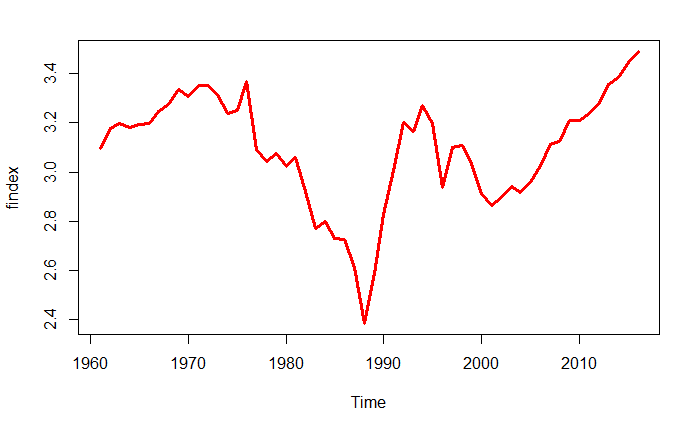

```r
ts.plot(findex, col=2, lwd=3)
```

```r
#tsf[,1] * (pc1$var$contrib[1,1]/100)) +
```

# Estimacion del Modelo con el Indice financiero

usar findex, GDPMX, GDPUS,

```r
f<-cbind(GDPMX$GDPMX, findex, GCF$GCF, GDPUS$GDPUS)
head(f)
```

```
Time Series:
Start = 1961
End = 1966
Frequency = 1
     GDPMX$GDPMX   findex  GCF$GCF GDPUS$GDPUS
1961    8.277389 3.096328 2.865836    9.779004
1962    8.291606 3.178022 2.800626    9.822836
1963    8.338308 3.196147 2.910904    9.851504
1964    8.419702 3.181136 2.937290    9.893994
1965    8.457372 3.194855 3.008690    9.943527
1966    8.485917 3.197767 2.968178    9.994953
```

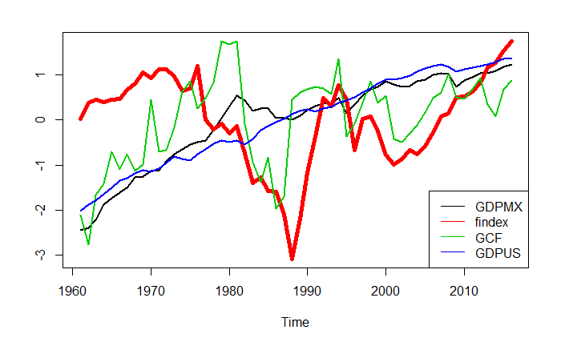

```r
f<-ts(f, names=c("GDPMX", "findex", "GCF", "GDPUS"), start= min(PCDM$yr), end=max(PCDM$yr), frequency=1)
ts.plot(scale(f), col=c(1,2,3,4), lwd=c(2,5,2,2))
legend("bottomright", colnames(f), col = c(1:4), lty = 1)
```

```r
#f<-cbind(GDPMX$GDPMX, findex,GDPUS$GDPUS)
#f<-ts(f,start= min(PCDM$yr), end=max(PCDM$yr), frequency=1)
#ts.plot(scale(f), col=c(1,2,3), lwd=c(2,2,2))
```

# Prueba de Raíz unitaria

Verificamos que son I(1)

```r
adf_matm <- matrix(0, ncol(f), 2)
rownames(adf_matm) <- colnames(f)
colnames(adf_matm) <- c("levels", "fd")
for(i in 1 : ncol(f)){
  adf_matm[i,"levels"] <- adf(f[,i], "none")$p.value
  adf_matm[i,"fd"] <- adf(diff(f[,i]), "none")$p.value
}
```

```
p-value greater than printed p-valuep-value smaller than printed p-valuep-value smaller than printed p-valuep-value smaller than printed p-valuep-value greater than printed p-value
```

```r
adf_matm
```

```
          levels       fd
GDPMX  0.9900000 0.010000
findex 0.6767132 0.010000
GCF    0.7849457 0.010000
GDPUS  0.9900000 0.029295
```

# Estimar

La estimación sera con US GDP como variable de control

```r
p <- VARselect(f,lag.max=7, type = "const")$selection["AIC(n)"]
p
```

```
AIC(n)
     7
```

```r
#pero escogeremos 6 por periodo sexenal
p <- 6
# estimamos el VAR
varf <- VAR(f, p = p, type = "const")
roots(varf)
```

```
 [1] 0.9780061 0.9589277 0.9589277 0.9491927 0.9491927 0.9040527 0.9040527 0.8776041
 [9] 0.8776041 0.8757041 0.8757041 0.8457259 0.8457259 0.8366290 0.8141041 0.8141041
[17] 0.8105202 0.8105202 0.7792320 0.7792320 0.7697853 0.7697853 0.7695558 0.7695558
```

# Estimacion de los residuales.

```r
regref<-lm(f[,"GDPMX"]~f[,"findex"]+f[,"GCF"]+ f[,"GDPUS"])
coeftest(regref)
```

```
t test of coefficients:

               Estimate Std. Error t value  Pr(>|t|)
(Intercept)    0.954661   0.334830  2.8512  0.006233 **
f[, "findex"] -0.130949   0.038792 -3.3757  0.001399 **
f[, "GCF"]     0.550371   0.101818  5.4054 1.643e-06 ***
f[, "GDPUS"]   0.637358   0.031837 20.0194 < 2.2e-16 ***
---
Signif. codes:  0 ‘***’ 0.001 ‘**’ 0.01 ‘*’ 0.05 ‘.’ 0.1 ‘ ’ 1
```

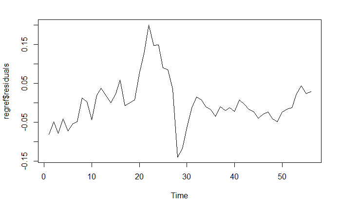

```r
ts.plot(regref$residuals)
```

```r
adf(resid(regref))
```

```
p-value smaller than printed p-value
```

```
    Augmented Dickey-Fuller Test

data:  resid(regref)
Dickey-Fuller = -2.7036, Lag order = 3, p-value = 0.01
alternative hypothesis: stationary
```

# Pruebas de diagnóstico

```r
arch.test(varf)
```

```
    ARCH (multivariate)

data:  Residuals of VAR object varf
Chi-squared = 450, df = 500, p-value = 0.9469
```

```r
serial.test(varf)
```

```
    Portmanteau Test (asymptotic)

data:  Residuals of VAR object varf
Chi-squared = 175.51, df = 160, p-value = 0.1901
```

# Analisis de Causalidad

Analizar si la causalidad tiene una representación económica en este ejericicio

```r
#causality(varf,cause=c("findex", "GDPUS"))
causalidad <- matrix(0, ncol(f),1)
rownames(causalidad) <-colnames(f)
for (i in 1 : ncol(f)) {
 causalidad[i,] <-causality(varf, cause =colnames(f)[i])$Granger$p.value
}
causalidad
```

```
             [,1]
GDPMX  0.22969222
findex 0.34900468
GCF    0.33965848
GDPUS  0.01612782
```

# VEC

```r
johaf <- ca.jo(f, type="eigen", ecdet = "const", K = p)
summary(johaf)
```

```
######################
# Johansen-Procedure #
######################

Test type: maximal eigenvalue statistic (lambda max) , without linear trend and constant in cointegration

Eigenvalues (lambda):
[1] 5.447543e-01 3.914367e-01 2.023497e-01 1.418916e-01 7.095912e-17

Values of teststatistic and critical values of test:

          test 10pct  5pct  1pct
r <= 3 |  7.65  7.52  9.24 12.97
r <= 2 | 11.30 13.75 15.67 20.20
r <= 1 | 24.83 19.77 22.00 26.81
r = 0  | 39.35 25.56 28.14 33.24

Eigenvectors, normalised to first column:
(These are the cointegration relations)

             GDPMX.l6  findex.l6      GCF.l6   GDPUS.l6   constant
GDPMX.l6   1.00000000  1.0000000   1.0000000  1.0000000  1.0000000
findex.l6 -0.04995704  0.3437950   0.2569718  0.1412247  0.4563704
GCF.l6    -1.52283818 -0.4762169 -23.3411892 -0.3268711 -1.0623350
GDPUS.l6  -0.41000138 -0.5950719  -1.1251248 -0.6714730 -0.2793582
constant   0.20013369 -2.3600225  76.7191508 -1.2873170 -4.1117792

Weights W:
(This is the loading matrix)

            GDPMX.l6  findex.l6      GCF.l6    GDPUS.l6      constant
GDPMX.d  -0.36557208 -0.1379700 0.006726280 -0.08406164  3.995773e-14
findex.d  0.50530230 -1.1142072 0.010517666 -0.24600942  1.376424e-12
GCF.d    -0.06208865  0.3830637 0.017581159 -0.25345489 -9.595859e-13
GDPUS.d  -0.11662464 -0.1127177 0.004280669  0.10353727  1.649292e-13
```

# Relaciones de Cointegración.

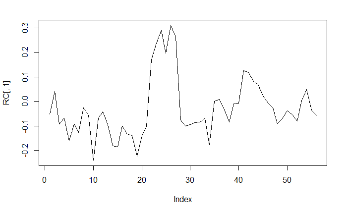

```r
RC <- cbind(f, 1)%*%johaf@V
plot(RC[,1], type="l")
```

# Prueba de estacionariedad a la relación de cointegración

```r
adf(RC[,1])
```

```
p-value smaller than printed p-value
```

```
    Augmented Dickey-Fuller Test

data:  RC[, 1]
Dickey-Fuller = -2.619, Lag order = 3, p-value = 0.01
alternative hypothesis: stationary
```

# Estimación VEC por OLS

Veremos si el término de corrección de error en el VEC resulta significativo.

ect1 debe ser negativo y significativo.

```r
vecols<- cajorls(johaf,r=1)
summary(vecols$rlm)
```

```
Response GDPMX.d :

Call:
lm(formula = GDPMX.d ~ ect1 + GDPMX.dl1 + findex.dl1 + GCF.dl1 +
    GDPUS.dl1 + GDPMX.dl2 + findex.dl2 + GCF.dl2 + GDPUS.dl2 +
    GDPMX.dl3 + findex.dl3 + GCF.dl3 + GDPUS.dl3 + GDPMX.dl4 +
    findex.dl4 + GCF.dl4 + GDPUS.dl4 + GDPMX.dl5 + findex.dl5 +
    GCF.dl5 + GDPUS.dl5 - 1, data = data.mat)

Residuals:
      Min        1Q    Median        3Q       Max
-0.075145 -0.010152  0.001159  0.015058  0.045368

Coefficients:
            Estimate Std. Error t value Pr(>|t|)
ect1       -0.365572   0.108228  -3.378 0.002098 **
GDPMX.dl1  -0.439620   0.253090  -1.737 0.092998 .
findex.dl1 -0.044463   0.055210  -0.805 0.427174
GCF.dl1     0.138731   0.103472   1.341 0.190407
GDPUS.dl1   0.520460   0.256196   2.031 0.051458 .
GDPMX.dl2  -0.658099   0.257743  -2.553 0.016192 *
findex.dl2 -0.009786   0.054310  -0.180 0.858258
GCF.dl2     0.317608   0.106004   2.996 0.005552 **
GDPUS.dl2   0.540057   0.291363   1.854 0.074001 .
GDPMX.dl3  -0.652658   0.244432  -2.670 0.012296 *
findex.dl3 -0.010690   0.052075  -0.205 0.838793
GCF.dl3     0.417190   0.122461   3.407 0.001946 **
GDPUS.dl3   0.164562   0.298523   0.551 0.585682
GDPMX.dl4  -0.510040   0.250899  -2.033 0.051312 .
findex.dl4 -0.085698   0.050344  -1.702 0.099407 .
GCF.dl4     0.493786   0.145821   3.386 0.002053 **
GDPUS.dl4   0.722105   0.297978   2.423 0.021849 *
GDPMX.dl5  -0.640121   0.251905  -2.541 0.016659 *
findex.dl5  0.006887   0.049686   0.139 0.890720
GCF.dl5     0.618289   0.155792   3.969 0.000436 ***
GDPUS.dl5   0.121122   0.321139   0.377 0.708797
---
Signif. codes:  0 ‘***’ 0.001 ‘**’ 0.01 ‘*’ 0.05 ‘.’ 0.1 ‘ ’ 1

Residual standard error: 0.02956 on 29 degrees of freedom
```

[output cut: 119 more lines]

```
GDPUS.dl3   0.209121   0.211433   0.989   0.3308
GDPMX.dl4  -0.123468   0.177703  -0.695   0.4927
findex.dl4 -0.016061   0.035657  -0.450   0.6558
GCF.dl4     0.062763   0.103280   0.608   0.5481
GDPUS.dl4   0.088456   0.211047   0.419   0.6782
GDPMX.dl5  -0.099797   0.178416  -0.559   0.5802
findex.dl5  0.011747   0.035191   0.334   0.7409
GCF.dl5     0.099226   0.110342   0.899   0.3759
GDPUS.dl5   0.484192   0.227451   2.129   0.0419 *
---
Signif. codes:  0 ‘***’ 0.001 ‘**’ 0.01 ‘*’ 0.05 ‘.’ 0.1 ‘ ’ 1

Residual standard error: 0.02094 on 29 degrees of freedom
Multiple R-squared:  0.6266,    Adjusted R-squared:  0.3561
F-statistic: 2.317 on 21 and 29 DF,  p-value: 0.01827
```

# Interpretación del Vector de Cointegracion

La relación es positiva,

```r
coefB(vecols)
```

```
                 ect1
GDPMX.l6   1.00000000
findex.l6 -0.04995704
GCF.l6    -1.52283818
GDPUS.l6  -0.41000138
constant   0.20013369
```

# VEC to Var

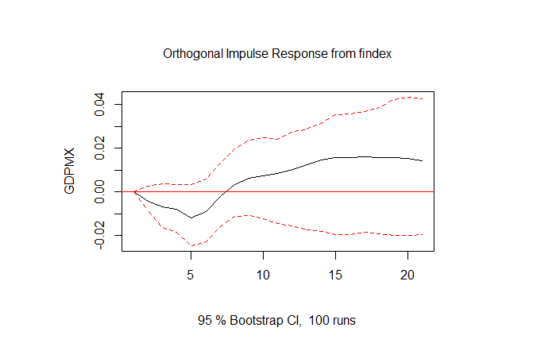

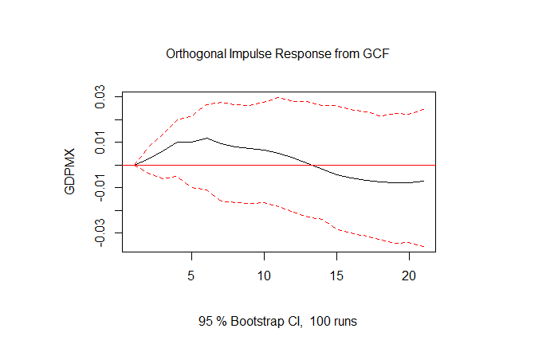

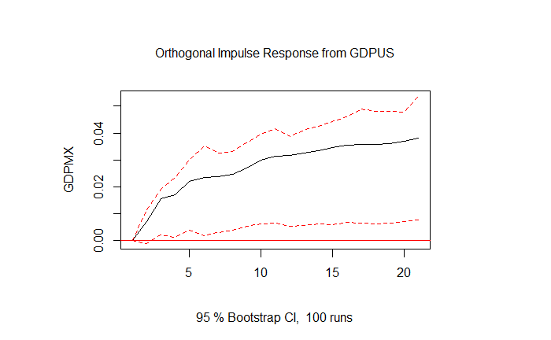

```r
varf2<- vec2var(johaf,r=1)
plot(irf(varf2, impulse = c("findex","GCF","GDPUS"),
         response = "GDPMX", n.ahead=20))
```

# Funcion impulso respuesa

Las graficas no convergen a 0

```r
arch.test(varf2)
```

```
    ARCH (multivariate)

data:  Residuals of VAR object varf2
Chi-squared = 450, df = 500, p-value = 0.9469
```

```r
serial.test(varf2)
```

```
    Portmanteau Test (asymptotic)

data:  Residuals of VAR object varf2
Chi-squared = 169.68, df = 164, p-value = 0.3644
```